# Examples

Source: [`vignettes/articles/examples.qmd`](https://github.com/xability/r-maidr/blob/main/vignettes/articles/examples.qmd)

Making accessible data representation with **maidr** is easy and straightforward. If you already have data visualization code using **ggplot2** or **Base R**, you can make your plots accessible with maidr in just a few lines of code.

Simply load the maidr package and call `maidr_on()`. When plots are printed in a document, maidr will automatically generate accessible versions. You can then interact with the accessible versions using keyboard shortcuts (refer to the table below).

| Key | Action |
| --- | --- |
| **Left / Right** | Navigate between data points |
| **B** | Toggle braille mode |
| **T** | Toggle text mode |
| **S** | Toggle sonification (hear the data) |
| **R** | Toggle review mode |

## When to Use Each Plot Type

| Plot Type | Best For | Example Use Case |
| --- | --- | --- |
| **Bar Chart** | Comparing categories | Sales by product |
| **Pie Chart** | Parts of a whole | Market share by brand |
| **Histogram** | Showing distributions | Test score frequencies |
| **Scatter Plot** | Relationships between variables | Height vs weight |
| **Line Plot** | Trends over time/order | Stock prices |
| **Step Plot** | Piecewise-constant state over time | A sleep-stage hypnogram |
| **Box Plot** | Distribution comparison | Salary by department |
| **Violin Plot** | Distribution shape comparison | Gene expression by group |
| **Candlestick (OHLC)** | Financial OHLC time-series | Stock price movements |
| **Heatmap** | Matrix relationships | Correlation matrices |
| **Density** | Smooth distributions | Probability density |
| **Faceted** | Comparing subgroups | Regional sales trends |
| **Multi-Panel** | Multiple related views | Dashboard layouts |
| **Multi-Layered** | Combining visualizations | Histogram + density overlay |

## Bar Plots

### Simple Bar Chart

A simple bar chart compares values across categories. Each bar represents one category with its height proportional to its value.

#### ggplot2

```r
bar_data <- data.frame(
  Product = c("Laptop", "Tablet", "Phone", "Monitor"),
  Sales = c(150, 230, 180, 290)
)

p <- ggplot(bar_data, aes(x = Product, y = Sales)) +
  geom_bar(stat = "identity", fill = "steelblue") +
  labs(
    title = "Product Sales by Category",
    x = "Product",
    y = "Sales (units)"
  ) +
  theme_minimal()

p
```

[interactive chart not shown]

#### Base R

```r
products <- c("Laptop", "Tablet", "Phone", "Monitor")
sales <- c(150, 230, 180, 290)

barplot(sales,
  names.arg = products,
  col = "steelblue",
  main = "Product Sales by Category",
  xlab = "Product",
  ylab = "Sales (units)"
)
```

[interactive chart not shown]

### Dodged / Grouped Bar Chart

A dodged bar chart places bars for each sub-group side by side, making it easy to compare values within and across categories.

#### ggplot2

```r
dodged_data <- data.frame(
  Region = rep(c("North", "South", "East"), each = 2),
  Quarter = rep(c("Q1", "Q2"), 3),
  Revenue = c(120, 150, 200, 180, 160, 210)
)

p <- ggplot(dodged_data, aes(x = Region, y = Revenue, fill = Quarter)) +
  geom_bar(stat = "identity", position = position_dodge(width = 0.8)) +
  labs(title = "Quarterly Revenue by Region") +
  scale_fill_manual(values = c("steelblue", "coral")) +
  theme_minimal()

p
```

[interactive chart not shown]

#### Base R

```r
revenue_matrix <- matrix(c(120, 150, 200, 180, 160, 210), nrow = 2)
rownames(revenue_matrix) <- c("Q1", "Q2")
barplot(revenue_matrix,
  beside = TRUE,
  names.arg = c("North", "South", "East"),
  col = c("steelblue", "coral"),
  legend.text = rownames(revenue_matrix),
  main = "Quarterly Revenue by Region",
  xlab = "Region",
  ylab = "Revenue"
)
```

[interactive chart not shown]

### Stacked Bar Chart

A stacked bar chart layers sub-groups on top of each other within each category, showing both individual contributions and the total.

#### ggplot2

```r
stacked_data <- data.frame(
  Year = rep(c("2022", "2023", "2024"), each = 3),
  Source = rep(c("Solar", "Wind", "Hydro"), 3),
  Output = c(40, 30, 50, 55, 45, 48, 70, 60, 52)
)

p <- ggplot(stacked_data, aes(x = Year, y = Output, fill = Source)) +
  geom_bar(stat = "identity", position = position_stack()) +
  labs(
    title = "Renewable Energy Output by Source",
    y = "Output (GWh)"
  ) +
  scale_fill_manual(values = c("#2ecc71", "#3498db", "#9b59b6")) +
  theme_minimal()

p
```

[interactive chart not shown]

#### Base R

```r
energy_matrix <- matrix(
  c(40, 30, 50, 55, 45, 48, 70, 60, 52),
  nrow = 3
)
rownames(energy_matrix) <- c("Solar", "Wind", "Hydro")
barplot(energy_matrix,
  beside = FALSE,
  names.arg = c("2022", "2023", "2024"),
  col = c("#2ecc71", "#3498db", "#9b59b6"),
  legend.text = rownames(energy_matrix),
  main = "Renewable Energy Output by Source",
  xlab = "Year",
  ylab = "Output (GWh)"
)
```

[interactive chart not shown]

## Pie Chart

A pie chart splits a whole into wedges, one per category, each wedge’s angle proportional to its share. maidr announces every slice by name and value, and derives its percentage of the total for you.

#### ggplot2

ggplot2 has no pie geom: a pie is a single stacked column bent around by `coord_polar("y")`, so `x` is the literal `""` and the categories go on `fill`. `coord_radial(theta = "y")` works the same way. Note that `coord_polar("x")` draws a coxcomb instead, which maidr still describes as a bar chart.

```r
market_share <- data.frame(
  Browser = c("Chrome", "Safari", "Edge", "Firefox"),
  Share = c(64, 19, 5, 3)
)

p <- ggplot(market_share, aes(x = "", y = Share, fill = Browser)) +
  geom_col(width = 1) +
  coord_polar("y") +
  labs(
    title = "Browser Market Share",
    fill = "Browser",
    y = "Share (%)"
  ) +
  theme_void()

p
```

[interactive chart not shown]

#### Base R

```r
shares <- c(Chrome = 64, Safari = 19, Edge = 5, Firefox = 3)
pie(shares,
  col = c("#3498db", "#2ecc71", "#9b59b6", "#e67e22"),
  main = "Browser Market Share",
  xlab = "Browser",
  ylab = "Share (%)"
)
```

[interactive chart not shown]

## Word Cloud

A word cloud is the extreme case of a chart that carries real data while being readable only by eye: each term’s weight is drawn as **glyph size** and written down nowhere on the page. Structurally it is a categorical label and a magnitude, so maidr reads it as a term and its number.

> **Experimental.** `word_cloud` is one of the experimental layer types. It has not been through a user study, and it may change without a deprecation period. See the experimental table in the README.

> **Note:** Word clouds are a Base R feature. ggplot2 has no word cloud geom, and the packages that add one draw through their own devices rather than through a layer maidr can read.

> **Requires the {wordcloud} package.** Install with `install.packages("wordcloud")`.

#### Base R

The counts you pass survive into the reading, so the weight axis honestly says **Occurrences**. (The Python binding cannot: `wordcloud.WordCloud` divides every frequency by the largest and keeps only the ratio, so py-maidr announces a *relative* frequency. Same chart, two different honest readings.)

```r
mentions <- c(
  accessibility = 412, sonification = 300, braille = 250,
  screenreader = 190, keyboard = 155, contrast = 120
)

maidr::wordcloud(
  words = names(mentions),
  freq = mentions,
  min.freq = 1,
  random.order = FALSE,
  colors = c(
    "#3498db", "#2ecc71", "#9b59b6",
    "#e67e22", "#e74c3c", "#16a085"
  )
)
```

[interactive chart not shown]

> **Attach order matters.** `library(wordcloud)` after `library(maidr)` puts `package:wordcloud` ahead of `package:maidr` on the search path, so a bare `wordcloud()` call reaches the wordcloud package directly and maidr never records it — the chart draws, but `show()` and `save_html()` then report that no Base R plot was found. Measured on a three-term cloud:

> | How it is called | Recorded? |
> | --- | --- |
> | `library(maidr)` then `library(wordcloud)`, bare `wordcloud()` | **no** |
> | `library(wordcloud)` then `library(maidr)`, bare `wordcloud()` | yes |
> | `maidr::wordcloud()` | yes |

> Either attach `wordcloud` **before** `maidr`, or call `maidr::wordcloud()` explicitly as above, which works in either order.

> **No highlighting.** `wordcloud()` draws each term with a bare `text()` call at a rotation chosen by `rot.per`, and nothing names those — the exported SVG carries no `id` attributes at all. So a word cloud is read without a visual highlight, rather than pairing the terms with whatever else happened to resolve.

Two of `wordcloud()`’s arguments decide **which** terms are drawn, and the reading replicates both so it never announces a term the chart left out: `min.freq` (default 3) drops anything rarer, and `max.words` keeps only the heaviest. `wordcloud()` also lowers `min.freq` to 0 when it exceeds every frequency, which is what stops a cloud of rare terms coming out empty; that rule is copied rather than approximated.

## Histogram

A histogram shows the frequency distribution of a continuous variable by grouping values into bins. The height of each bar indicates how many observations fall within that range.

#### ggplot2

```r
exam_scores <- data.frame(score = c(
  rnorm(500, mean = 72, sd = 10),
  rnorm(500, mean = 85, sd = 8)
))

p <- ggplot(exam_scores, aes(x = score)) +
  geom_histogram(bins = 25, fill = "skyblue", color = "white") +
  labs(
    title = "Distribution of Exam Scores",
    x = "Score",
    y = "Frequency"
  ) +
  theme_minimal()

p
```

[interactive chart not shown]

#### Base R

```r
scores <- c(rnorm(500, mean = 72, sd = 10), rnorm(500, mean = 85, sd = 8))
hist(scores,
  breaks = 25,
  col = "skyblue",
  border = "white",
  main = "Distribution of Exam Scores",
  xlab = "Score",
  ylab = "Frequency"
)
```

[interactive chart not shown]

## Scatter Plot

A scatter plot displays the relationship between two continuous variables. Each point represents one observation, and color can encode a third categorical variable.

#### ggplot2

```r
car_data <- data.frame(
  weight = mtcars$wt,
  mpg = mtcars$mpg,
  cylinders = factor(mtcars$cyl)
)

p <- ggplot(car_data, aes(x = weight, y = mpg, color = cylinders)) +
  geom_point(size = 3, alpha = 0.8) +
  labs(
    title = "Fuel Efficiency vs Vehicle Weight",
    x = "Weight (1000 lbs)",
    y = "Miles per Gallon",
    color = "Cylinders"
  ) +
  theme_minimal()

p
```

[interactive chart not shown]

#### Base R

```r
colors <- c("4" = "steelblue", "6" = "coral", "8" = "forestgreen")
plot(mtcars$wt, mtcars$mpg,
  pch = 19,
  col = colors[as.character(mtcars$cyl)],
  main = "Fuel Efficiency vs Vehicle Weight",
  xlab = "Weight (1000 lbs)",
  ylab = "Miles per Gallon"
)
legend("topright",
  legend = c("4 cyl", "6 cyl", "8 cyl"),
  col = colors, pch = 19
)
```

[interactive chart not shown]

## Line Plots

### Single Line

A line plot connects ordered data points, making it ideal for showing trends over time or sequential categories.

#### ggplot2

```r
temp_data <- data.frame(
  Month = factor(month.abb, levels = month.abb),
  Temperature = c(2, 4, 10, 15, 20, 25, 28, 27, 22, 15, 8, 3)
)

p <- ggplot(temp_data, aes(x = Month, y = Temperature, group = 1)) +
  geom_line(color = "tomato", linewidth = 1.2) +
  labs(
    title = "Average Monthly Temperature",
    y = "Temperature (C)"
  ) +
  theme_minimal()

p
```

[interactive chart not shown]

#### Base R

```r
months <- 1:12
temps <- c(2, 4, 10, 15, 20, 25, 28, 27, 22, 15, 8, 3)
plot(months, temps,
  type = "l", col = "tomato", lwd = 2,
  main = "Average Monthly Temperature",
  xlab = "Month", ylab = "Temperature (C)",
  xaxt = "n"
)
axis(1, at = 1:12, labels = month.abb)
```

[interactive chart not shown]

### Multiple Lines

A multi-line plot overlays several series on the same axes, enabling direct comparison of trends across groups.

#### ggplot2

```r
multi_line <- data.frame(
  Year = rep(2015:2024, 3),
  Users = c(
    10, 15, 22, 35, 50, 72, 95, 120, 150, 180,
    8, 12, 18, 25, 38, 55, 70, 88, 110, 135,
    5, 8, 14, 20, 30, 42, 58, 75, 95, 118
  ),
  Platform = rep(c("Mobile", "Desktop", "Tablet"), each = 10)
)

p <- ggplot(multi_line, aes(x = Year, y = Users, color = Platform)) +
  geom_line(linewidth = 1.2) +
  labs(
    title = "Platform Users Over Time",
    y = "Users (millions)"
  ) +
  theme_minimal()

p
```

[interactive chart not shown]

#### Base R

```r
years <- 2015:2024
users <- cbind(
  Mobile  = c(10, 15, 22, 35, 50, 72, 95, 120, 150, 180),
  Desktop = c(8, 12, 18, 25, 38, 55, 70, 88, 110, 135),
  Tablet  = c(5, 8, 14, 20, 30, 42, 58, 75, 95, 118)
)

matplot(years, users,
  type = "l", lwd = 2,
  col = c("steelblue", "coral", "forestgreen"),
  lty = 1,
  main = "Platform Users Over Time",
  xlab = "Year", ylab = "Users (millions)"
)
legend("topleft",
  legend = colnames(users),
  col = c("steelblue", "coral", "forestgreen"),
  lwd = 2
)
```

[interactive chart not shown]

## Box Plot

A box plot summarizes a distribution using its five-number summary: minimum, first quartile (Q1), median (Q2), third quartile (Q3), and maximum. Outliers appear as individual points.

#### ggplot2

```r
p <- ggplot(iris, aes(x = Species, y = Sepal.Length)) +
  geom_boxplot(fill = "lightblue", alpha = 0.7) +
  labs(
    title = "Sepal Length by Iris Species",
    x = "Species",
    y = "Sepal Length (cm)"
  ) +
  theme_minimal()

p
```

[interactive chart not shown]

#### Base R

```r
boxplot(Sepal.Length ~ Species,
  data = iris,
  col = "lightblue",
  main = "Sepal Length by Iris Species",
  xlab = "Species",
  ylab = "Sepal Length (cm)"
)
```

[interactive chart not shown]

## Violin Plot

A violin plot combines kernel density estimation (KDE) curves with box-summary statistics, providing a richer view of the data distribution than a box plot alone. MAIDR renders each violin as two navigable layers: a **box** layer (min, Q1, median, Q3, max) and a **KDE** layer (density curve).

> **Note:** Violin plots are a ggplot2-only feature.

```r
p <- ggplot(mtcars, aes(x = factor(cyl), y = mpg)) +
  geom_violin(fill = "lightblue", alpha = 0.7) +
  labs(
    title = "MPG Distribution by Cylinder Count",
    x = "Cylinders",
    y = "Miles per Gallon"
  ) +
  theme_minimal()

p
```

[interactive chart not shown]

## Step Plot

A step plot suits a value that is **piecewise constant**: it is held across an interval and then jumps, rather than drifting between samples the way a line implies. The canonical case is a **hypnogram** — the sleep stage a sleep study scores for each epoch of the night.

MAIDR reports the layer’s step convention (`hv`, `vh`, or `mid`) so the description says where the value jumps, and offers a **Transitions** rotor mode that moves between the moments the level changes rather than sample by sample.

When the y aesthetic is an ordinal factor, the level *name* is announced (“REM”, “N2”, “Awake”) while the numeric level still drives sonification and braille — so the shape of the night is audible and the stage is speakable.

#### ggplot2

```r
hypnogram <- data.frame(
  hour = seq(0, 7.5, by = 0.5),
  stage = factor(
    c(
      "Awake", "N1", "N2", "N3", "N3", "N2", "REM", "N2",
      "N3", "N3", "N2", "REM", "N2", "N1", "REM", "Awake"
    ),
    levels = c("N3", "N2", "N1", "REM", "Awake")
  )
)

p <- ggplot(hypnogram, aes(x = hour, y = stage, group = 1)) +
  geom_step(direction = "hv", color = "steelblue", linewidth = 1) +
  scale_x_continuous(breaks = 0:8) +
  labs(
    title = "Overnight Hypnogram",
    x = "Hours after lights out",
    y = "Sleep stage"
  ) +
  theme_minimal()

p
```

[interactive chart not shown]

`geom_step(direction = )` accepts `"hv"` (the default — hold, then jump at the next x), `"vh"` (jump at the current x, then hold), and `"mid"` (jump midway between x values). All three are passed through to MAIDR unchanged.

#### Base R

`plot(type = "s")` draws the horizontal segment first, matching `"hv"`; `plot(type = "S")` draws the vertical segment first, matching `"vh"`.

```r
hours <- seq(0, 7.5, by = 0.5)
stage_names <- c("N3", "N2", "N1", "REM", "Awake")
stage <- c(
  5, 3, 2, 1, 1, 2, 4, 2,
  1, 1, 2, 4, 2, 3, 4, 5
)

plot(hours, stage,
  type = "s", col = "steelblue", lwd = 2,
  main = "Overnight Hypnogram",
  xlab = "Hours after lights out", ylab = "Sleep stage",
  yaxt = "n"
)
axis(2, at = seq_along(stage_names), labels = stage_names, las = 1)
```

[interactive chart not shown]

## Candlestick (OHLC) Charts

A candlestick chart visualizes Open-High-Low-Close (OHLC) financial data. Each candle represents one trading period and exposes the four price fields plus a computed **trend** (Bull / Bear / Neutral) and **volatility** (high − low). When volume data is present and combined with a volume panel via patchwork, each candle’s `volume` is also embedded in the data point.

> **Note:** Requires the {tidyquant} package for the ggplot2 path and {quantmod} for the Base R path. Install with `install.packages(c("tidyquant", "patchwork", "quantmod"))`.

### Support matrix: what works in each system

The accessible HTML pipeline supports different sets of overlays for the ggplot2 and Base R candlestick paths. Use the ggplot2 + tidyquant + patchwork path whenever you need moving averages or a volume sub-panel.

| Feature | ggplot2 (`tidyquant::geom_candlestick`) | Base R (`quantmod::chartSeries`) |
| --- | --- | --- |
| Plain OHLC candlestick | ✅ Supported | ✅ Supported (OHLC-only input) |
| Moving-average overlay | ✅ via `tidyquant::geom_ma()` (one or more layers; auto-collapsed into a single multi-series line layer) | ❌ `TA = "addSMA()"` / `"addEMA()"` not supported |
| Volume sub-panel | ✅ via separate `geom_col()` + `patchwork::plot_layout()` (collapsed into the candlestick subplot, with `volume` embedded into each candle point) | ❌ `TA = "addVo()"` not supported; default `TA` with a `Volume` column also unsupported |
| Behavior when unsupported | n/a | One-time warning + fall back to native (non-accessible) graphics; advisory points users to the ggplot2 pipeline |

### Simple OHLC Candlestick

#### ggplot2

```r
library(tidyquant)

ohlc_simple <- data.frame(
  date  = as.Date(c("2023-01-02", "2023-01-03", "2023-01-04", "2023-01-05")),
  open  = c(100, 105, 110, 108),
  high  = c(115, 108, 112, 110),
  low   = c(95, 102, 105, 100),
  # Bull, Bear, Bull, Neutral
  close = c(110, 103, 111, 108)
)

p <- ggplot(
  ohlc_simple,
  aes(x = date, open = open, high = high, low = low, close = close)
) +
  geom_candlestick(
    colour_up = "darkgreen", colour_down = "red",
    fill_up = "darkgreen", fill_down = "red"
  ) +
  labs(
    title = "Sample OHLC Candlestick",
    subtitle = "Four trading days",
    x = "Date",
    y = "Price"
  ) +
  theme_minimal()

p
```

[interactive chart not shown]

### Candlestick with Moving Averages and Volume (ggplot2)

This example exercises the full accessible price + MA + volume pipeline: a candlestick layer, two `geom_ma()` overlays (5- and 10-day SMAs), and a separate volume bar panel composed via patchwork. MAIDR collapses the two `geom_ma()` overlays into a single multi-series line layer, and the candlestick + bar + line panels collapse to a single navigable subplot in which each candle also carries its `volume` field.

```r
library(tidyquant)
library(patchwork)

set.seed(42)
n_days <- 20
dates  <- seq(as.Date("2024-01-02"), by = "day", length.out = n_days)
opens  <- 100 + cumsum(rnorm(n_days, 0, 1.5))
closes <- opens + rnorm(n_days, 0, 1.2)
highs  <- pmax(opens, closes) + abs(rnorm(n_days, 1, 0.5))
lows   <- pmin(opens, closes) - abs(rnorm(n_days, 1, 0.5))
vols   <- as.integer(runif(n_days, 1e5, 5e5))

ohlcv <- data.frame(
  date   = dates,
  open   = round(opens, 2),
  high   = round(highs, 2),
  low    = round(lows, 2),
  close  = round(closes, 2),
  volume = vols
)

p_price <- ggplot(
  ohlcv,
  aes(x = date, open = open, high = high, low = low, close = close)
) +
  geom_candlestick(
    colour_up = "darkgreen", colour_down = "red",
    fill_up = "darkgreen", fill_down = "red"
  ) +
  geom_ma(aes(y = close), ma_fun = SMA, n = 5,
          colour = "blue", linetype = "dashed", linewidth = 0.8) +
  geom_ma(aes(y = close), ma_fun = SMA, n = 10,
          colour = "orange", linetype = "dotted", linewidth = 0.8) +
  labs(title = "OHLC with 5- and 10-day SMA", x = NULL, y = "Price") +
  theme_minimal()

p_volume <- ggplot(ohlcv, aes(x = date, y = volume)) +
  geom_col(fill = "steelblue", alpha = 0.7) +
  labs(x = "Date", y = "Volume") +
  theme_minimal()

p_price / p_volume + plot_layout(heights = c(3, 1), axes = "collect_x")
```

[interactive chart not shown]

### Base R Candlestick (quantmod)

The Base R path supports a plain OHLC candlestick via `quantmod::chartSeries(x, type = "candlesticks")`. Each row of the `xts`/`zoo` input is emitted as a navigable candle point with `value` (ISO date), `open`, `high`, `low`, `close`, computed `trend`, and `volatility`.

> **Limitations.** Technical-analysis overlays via the `TA` argument (e.g. `addVo()`, `addSMA()`, `addEMA()`) are **not supported** by the accessible HTML pipeline. The same applies to `chartSeries()`’s *default* `TA` whenever the input `xts` has a `Volume` column, since the default auto-adds `addVo()`. In all these cases maidr falls back to native (non-accessible) graphics with a one-time advisory pointing users to the ggplot2 + tidyquant + patchwork pipeline shown above. To opt in to accessible HTML for a Base R candlestick, supply OHLC data **without** a `Volume` column (default `TA` then becomes a no-op), or pass `TA = NULL` explicitly.

> **Attach order matters.** `library(quantmod)` after `library(maidr)` puts `package:quantmod` ahead of `package:maidr` on the search path, so a bare `chartSeries()` call reaches quantmod directly and maidr never records it — the chart draws, but `show()` and `save_html()` then report that no Base R plot was found. Either attach `quantmod` **before** `maidr`, or call `maidr::chartSeries()` explicitly as below, which works in either order.

```r
library(quantmod)

# OHLC-only xts (no Volume column) so the default TA is a no-op.
TST <- xts::xts(
  cbind(
    Open  = c(101.00, 102.00, 105.00, 103.50),
    High  = c(102.50, 105.50, 105.80, 104.50),
    Low   = c(100.50, 101.80, 103.00, 102.50),
    Close = c(102.00, 105.00, 103.50, 104.00)
  ),
  order.by = as.Date(c(
    "2024-01-12", "2024-01-13", "2024-01-14", "2024-01-15"
  ))
)
colnames(TST) <- c("TST.Open", "TST.High", "TST.Low", "TST.Close")

maidr::chartSeries(TST, type = "candlesticks", theme = "white", name = "TST")
```

[output not shown]

## Heat Map

A heatmap uses color intensity to represent values in a two-dimensional matrix. It is useful for spotting patterns, clusters, and outliers across two categorical dimensions.

#### ggplot2

```r
heatmap_data <- expand.grid(
  Day = c("Mon", "Tue", "Wed", "Thu", "Fri"),
  Hour = c("9am", "10am", "11am", "12pm", "1pm", "2pm", "3pm", "4pm")
)
heatmap_data$Visitors <- c(
  20, 35, 50, 45, 30,
  25, 40, 60, 55, 35,
  30, 55, 75, 70, 45,
  40, 65, 90, 85, 60,
  35, 50, 70, 65, 40,
  30, 45, 60, 55, 38,
  25, 40, 55, 50, 32,
  15, 30, 40, 35, 22
)

p <- ggplot(heatmap_data, aes(x = Day, y = Hour, fill = Visitors)) +
  geom_tile(color = "white") +
  scale_fill_gradient(low = "#f7fbff", high = "#08306b") +
  labs(title = "Website Visitors by Day and Hour") +
  theme_minimal()

p
```

[interactive chart not shown]

#### Base R

```r
visitors <- matrix(
  c(
    20, 35, 50, 45, 30,
    25, 40, 60, 55, 35,
    30, 55, 75, 70, 45,
    40, 65, 90, 85, 60,
    35, 50, 70, 65, 40,
    30, 45, 60, 55, 38,
    25, 40, 55, 50, 32,
    15, 30, 40, 35, 22
  ),
  nrow = 5
)
image(visitors,
  col = hcl.colors(20, "Blues"),
  main = "Website Visitors by Day and Hour",
  xlab = "Day",
  ylab = "Hour",
  axes = FALSE
)
axis(1,
  at = seq(0, 1, length.out = 5),
  labels = c("Mon", "Tue", "Wed", "Thu", "Fri")
)
axis(2,
  at = seq(0, 1, length.out = 8),
  labels = c("9am", "10am", "11am", "12pm", "1pm", "2pm", "3pm", "4pm")
)
```

[interactive chart not shown]

## KDE (Kernel Density Estimation) Plots

A density curve shows the estimated probability distribution of a continuous variable. It provides a smooth alternative to histograms for understanding the shape of data.

#### ggplot2

```r
density_values <- data.frame(value = c(
  rnorm(400, mean = 25, sd = 5),
  rnorm(600, mean = 40, sd = 8)
))

p <- ggplot(density_values, aes(x = value)) +
  geom_density(fill = "lightblue", alpha = 0.5, color = "steelblue") +
  labs(
    title = "Age Distribution of Survey Respondents",
    x = "Age",
    y = "Density"
  ) +
  theme_minimal()

p
```

[interactive chart not shown]

#### Base R

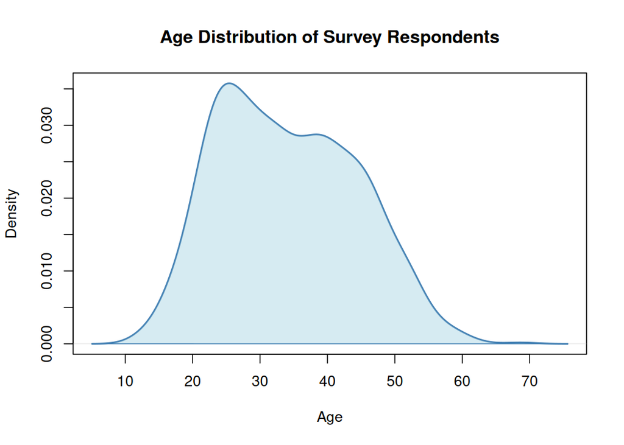

```r
ages <- c(rnorm(400, mean = 25, sd = 5), rnorm(600, mean = 40, sd = 8))
d <- density(ages)
plot(d,
  col = "steelblue", lwd = 2,
  main = "Age Distribution of Survey Respondents",
  xlab = "Age",
  ylab = "Density"
)
polygon(d, col = rgb(0.678, 0.847, 0.902, 0.5), border = "steelblue")
```

## Regression Plots

A scatter plot with a fitted regression line shows the relationship between two variables along with the best-fit model.

#### ggplot2

```r
p <- ggplot(mtcars, aes(x = wt, y = mpg)) +
  geom_point(color = "steelblue", size = 3) +
  geom_smooth(method = "lm", color = "red", se = TRUE) +
  labs(
    title = "Weight vs MPG with Linear Fit",
    x = "Weight (1000 lbs)",
    y = "Miles per Gallon"
  ) +
  theme_minimal()

p
```

[interactive chart not shown]

#### Base R

```r
plot(mtcars$wt, mtcars$mpg,
  pch = 19, col = "steelblue",
  main = "Weight vs MPG with Linear Fit",
  xlab = "Weight (1000 lbs)", ylab = "Miles per Gallon"
)
abline(lm(mpg ~ wt, data = mtcars), col = "red", lwd = 2)
```

[interactive chart not shown]

## Multi-Layered Plots

Multi-layered plots combine multiple visualization types in a single chart. For example, a histogram overlaid with a density curve, or a bar chart with a line overlay.

### Histogram with Density Overlay

#### ggplot2

```r
p <- ggplot(mtcars, aes(x = mpg)) +
  geom_histogram(
    aes(y = after_stat(density)),
    bins = 15, fill = "lightblue", color = "white"
  ) +
  geom_density(color = "red", linewidth = 1.2) +
  labs(title = "MPG: Histogram with Density Curve") +
  theme_minimal()

p
```

[interactive chart not shown]

#### Base R

```r
hist(mtcars$mpg,
  breaks = 15, freq = FALSE,
  col = "lightblue", border = "white",
  main = "MPG: Histogram with Density Curve",
  xlab = "Miles per Gallon",
  ylab = "Density"
)
lines(density(mtcars$mpg), col = "red", lwd = 2)
```

[interactive chart not shown]

### Bar Chart with Line Overlay

#### ggplot2

```r
combo_data <- data.frame(
  month = factor(month.abb[1:6], levels = month.abb[1:6]),
  sales = c(100, 120, 90, 150, 130, 160),
  target = c(110, 110, 110, 140, 140, 140)
)

p <- ggplot(combo_data, aes(x = month)) +
  geom_bar(aes(y = sales), stat = "identity", fill = "steelblue", alpha = 0.7) +
  geom_line(aes(y = target, group = 1), color = "red", linewidth = 1.5) +
  labs(title = "Monthly Sales vs Target", y = "Value") +
  theme_minimal()

p
```

[interactive chart not shown]

## Multi-Panel Plots (Multiple Subplots)

Multi-panel layouts arrange several independent plots in a grid. This is useful for dashboards or comparing different views of the same dataset.

#### ggplot2 (patchwork)

```r
library(patchwork)

# Line plot with currency formatting
line_df <- data.frame(
  Month = 1:8,
  Revenue = c(2500, 4200, 3100, 5500, 4300, 6700, 5600, 7800)
)
pw_line <- ggplot(line_df, aes(Month, Revenue)) +
  geom_line(color = "steelblue", linewidth = 1) +
  labs(title = "Monthly Revenue", x = "Month", y = "Revenue") +
  theme_minimal()

# Bar plot with rates
bar_df1 <- data.frame(
  Category = c("A", "B", "C", "D", "E"),
  Rate = c(0.15, 0.22, 0.18, 0.28, 0.17)
)
pw_bar1 <- ggplot(bar_df1, aes(Category, Rate)) +
  geom_bar(stat = "identity", fill = "forestgreen", alpha = 0.7) +
  labs(title = "Conversion Rates", x = "Category", y = "Rate") +
  theme_minimal()

# Bar plot with large numbers
bar_df2 <- data.frame(
  Category = c("A", "B", "C", "D", "E"),
  Count = c(125000, 98000, 145000, 112000, 88000)
)
pw_bar2 <- ggplot(bar_df2, aes(Category, Count)) +
  geom_bar(stat = "identity", fill = "royalblue", alpha = 0.7) +
  labs(title = "User Counts", x = "Category", y = "Count") +
  theme_minimal()

# Line plot with exponential growth
line_df2 <- data.frame(
  x = 1:8,
  y = 10^(seq(3, 6.5, length.out = 8))
)
pw_line2 <- ggplot(line_df2, aes(x, y)) +
  geom_line(color = "tomato", linewidth = 1) +
  labs(title = "Exponential Growth", x = "Time", y = "Value") +
  theme_minimal()

combined <- (pw_line + pw_bar1 + pw_bar2 + pw_line2) +
  plot_layout(ncol = 2)
combined
```

[interactive chart not shown]

#### Base R (par)

```r
par(mfrow = c(2, 2))

barplot(table(mtcars$cyl),
  col = "steelblue",
  main = "Cars by Cylinder Count",
  xlab = "Cylinders"
)

hist(mtcars$mpg,
  breaks = 12, col = "coral", border = "white",
  main = "MPG Distribution", xlab = "MPG"
)

plot(mtcars$wt, mtcars$mpg,
  pch = 19, col = "forestgreen",
  main = "MPG vs Weight",
  xlab = "Weight (1000 lbs)", ylab = "MPG"
)

boxplot(hp ~ gear,
  data = mtcars, col = "plum",
  main = "Horsepower by Gear Count",
  xlab = "Gears", ylab = "Horsepower"
)
```

[interactive chart not shown]

```r
invisible(par(mfrow = c(1, 1)))
```

## Facet Plots

Faceted plots split data into a grid of subplots by one or more grouping variables. Each panel shows the same type of chart for a different subset of the data. This is a ggplot2-only feature using `facet_wrap()` or `facet_grid()`.

### facet_wrap

```r
facet_data <- data.frame(
  x = rep(c("A", "B", "C", "D"), 4),
  y = c(
    30, 25, 35, 20,
    45, 30, 25, 40,
    20, 35, 30, 45,
    35, 40, 20, 30
  ),
  panel = rep(c("Group 1", "Group 2", "Group 3", "Group 4"), each = 4)
)

p <- ggplot(facet_data, aes(x = x, y = y)) +
  geom_bar(stat = "identity", fill = "steelblue") +
  facet_wrap(~panel, ncol = 2) +
  labs(title = "Sales by Category Across Groups", x = "Category", y = "Sales") +
  theme_minimal()

p
```

[interactive chart not shown]

### facet_grid

```r
p <- ggplot(mtcars, aes(x = wt, y = mpg)) +
  geom_point(size = 2, color = "steelblue") +
  facet_grid(vs ~ am,
    labeller = labeller(
      vs = c("0" = "V-engine", "1" = "Straight"),
      am = c("0" = "Automatic", "1" = "Manual")
    )
  ) +
  labs(
    title = "MPG vs Weight by Engine Type and Transmission",
    x = "Weight (1000 lbs)",
    y = "Miles per Gallon"
  ) +
  theme_minimal()

p
```

[interactive chart not shown]

## Experimental Base R Charts

Base R draws a long tail of statistical charts that have no ggplot2 equivalent maidr reads — a correlogram, a periodogram, a biplot, a star plot. maidr reads each of them by mapping it onto a layer type it already knows, so a chart drawn for the eye becomes a series a reader can walk.

> **Experimental.** Every layer type in this section is one of the experimental types. None has been through a user study, and each may change without a deprecation period. See the experimental table in the README.

> **Note:** Everything below is Base R, so no `#### ggplot2` counterpart is shown. Each section names the reading its chart gets, because the mapping is not always the one the chart’s name suggests — a correlogram is read as a lollipop, a conditional density plot as a 100% stacked area.

### Correlogram

`acf()`, `pacf()` and `ccf()` draw a spike per lag, and maidr reads each as a **lollipop**: one term per lag, carrying the correlation at that lag. The axes come from the function itself, so the reading says `Lag` against `ACF`, `Partial ACF` or `CCF` without being told.

`acf()` starts at lag 0, whose autocorrelation is always exactly 1, so the first term of an ACF is a constant rather than a measurement. `pacf()` has no lag 0 and starts at lag 1.

```r
acf(lh, lag.max = 5, main = "Luteinizing hormone: autocorrelation")
```

[interactive chart not shown]

```r
pacf(lh, lag.max = 5, main = "Luteinizing hormone: partial autocorrelation")
```

[interactive chart not shown]

`ccf()` correlates two series across negative and positive lags, so its terms are signed and the sign says which series leads.

```r
ccf(mdeaths, fdeaths, lag.max = 4, main = "Male vs female deaths")
```

[interactive chart not shown]

### Spectral Density

`spectrum()` estimates how a series’ variance is distributed across frequencies. maidr reads the periodogram as a **line** of `spectrum` against `frequency`.

```r
spectrum(lh, main = "Luteinizing hormone: spectral density")
```

[interactive chart not shown]

### Cumulative Periodogram

`cpgram()` draws the cumulative periodogram against its confidence band. The cumulative curve is read as a **step**; the band is drawing rather than data, and is not announced.

> **Note:** `cpgram()` labels only its x axis, so the reading carries `frequency` and no y label. It takes no `ylab` argument to supply one.

```r
cpgram(lh, main = "Luteinizing hormone: cumulative periodogram")
```

[interactive chart not shown]

### Seasonal Subseries

`monthplot()` breaks a seasonal series into one segment per cycle position, so every January sits together and the seasonal shape is read directly. maidr reads it as a **line**.

> **Note:** `monthplot()` has no default for `xlab` – the axis it writes carries the cycle labels, not a quantity – so x is named only when the call names it. Left out, y falls back to the series name — `nottem` here.

```r
monthplot(
  nottem,
  xlab = "Month", ylab = "Temperature (F)",
  main = "Nottingham temperatures by month"
)
```

[interactive chart not shown]

### Lag Plot

`lag.plot()` plots a series against itself shifted by *k*, which is how serial dependence is read by eye. maidr reads it as a **point** layer whose x axis is named for the shift — `lag 1` against the series.

```r
lag.plot(lh, lags = 1, main = "Luteinizing hormone against its own lag")
```

[interactive chart not shown]

### Partial Effects

`termplot()` draws each term’s fitted contribution against its own predictor, holding the rest fixed. maidr reads each panel as a **line**, labelled `partial for <term>` so the reading says it is a contribution rather than a fitted value.

```r
termplot(lm(mpg ~ wt, data = mtcars), main = "Partial effect of weight")
```

[interactive chart not shown]

### Biplot

`biplot()` puts observations and variable loadings on one pair of principal component axes. maidr reads the observations as a **point** layer on `PC1` and `PC2`, and each point carries its own row name, so a reader hears which observation they are on rather than a bare coordinate pair.

```r
biplot(prcomp(USArrests, scale. = TRUE), main = "US arrests: PC1 vs PC2")
```

[interactive chart not shown]

### Radar

`stars()` draws one star per row, with a ray per variable. maidr reads it as a **radar**: one series per observation, each carrying a value per variable.

> **Note:** A star plot has no x and y axes to name, so the reading carries no axis labels — the variable names come through as the rays themselves.

```r
stars(mtcars[1:5, 1:4], main = "Five cars over four measures")
```

[interactive chart not shown]

### Interaction Plot

`interaction.plot()` draws a line per level of the trace factor, so a non-parallel pair is the interaction. maidr reads one **line** per level and puts `trace.label` on the z axis, which is what names the two series apart.

```r
interaction.plot(ToothGrowth$dose, ToothGrowth$supp, ToothGrowth$len,
  xlab = "Dose (mg/day)", ylab = "Mean tooth length", trace.label = "Supplement"
)
```

[interactive chart not shown]

### Box Plot from Summary Statistics

`bxp()` draws a box plot from statistics already computed, rather than from raw data — which is exactly what `boxplot(plot = FALSE)` hands back. maidr reads it as a **box**, the same reading `boxplot()` gets, so a pre-summarised box is not a second-class one.

```r
bxp(boxplot(count ~ spray, data = InsectSprays, plot = FALSE),
  main = "Insect counts by spray"
)
```

[interactive chart not shown]

### Strip Chart

`stripchart()` is the one-dimensional scatter you reach for when a box plot would hide too few points. maidr reads **one point layer per group**, so the groups are navigated as separate series rather than flattened together.

```r
stripchart(count ~ spray,
  data = InsectSprays, method = "jitter",
  xlab = "Count", ylab = "Spray"
)
```

[interactive chart not shown]

### Dot Chart

`dotchart()` is Cleveland’s alternative to a bar chart for labelled values. maidr reads it as a **dot** layer.

```r
dotchart(VADeaths[, "Rural Male"],
  xlab = "Deaths per 1000", ylab = "Age group",
  main = "Virginia death rates, rural males"
)
```

[interactive chart not shown]

### Lollipop

`plot(type = "h")` draws a vertical spike down to each value. maidr reads it as a **lollipop**, the same type the correlogram uses.

```r
plot(1:8, c(2, 5, 3, 9, 4, 7, 6, 8),
  type = "h", xlab = "Index", ylab = "Value", main = "Spikes"
)
```

[interactive chart not shown]

### Mosaic and Spine Plots

Both tile a contingency table so that area is proportion, and maidr reads both as a **mosaic**: the y axis is `Proportion`, and the second factor is named on z. `mosaicplot()` takes a two-way table.

```r
mosaicplot(HairEyeColor[, , "Male"], main = "Hair and eye colour, males")
```

[interactive chart not shown]

`spineplot()` takes a factor response against one predictor, which makes it the two-column case of the same reading.

```r
spineplot(factor(am) ~ wt, data = mtcars, xlab = "Weight", ylab = "Transmission")
```

[interactive chart not shown]

### Conditional Density

`cdplot()` is the continuous-predictor counterpart to a spine plot: it draws how the conditional distribution of a factor shifts along a numeric axis. maidr reads it as a **100% stacked area**, since every vertical slice sums to one.

```r
cdplot(factor(am) ~ mpg, data = mtcars, xlab = "Miles per gallon")
```

[interactive chart not shown]

### Association Plot

`assocplot()` states one signed Pearson residual per cell of a contingency table — how far that cell sits from independence. maidr reads it as a **heat**: a named grid navigated row then column, with the residual on z, so the sign and size of each departure are read out per cell.

```r
assocplot(HairEyeColor[, , "Male"], main = "Hair and eye colour: residuals")
```

[interactive chart not shown]

### Filled Contour

`filled.contour()` shades the bands between contour lines. maidr reads the **contour** levels themselves, so a reader walks the level curves rather than the shading.

> **Note:** Passing `x` and `y` is worth doing here. Given only `z`, `filled.contour()` positions the grid on 0–1 and the reading has no axis labels at all; given real coordinates it announces them in their own units.

```r
filled.contour(
  x = 10 * (1:nrow(volcano)), y = 10 * (1:ncol(volcano)), z = volcano,
  xlab = "Easting (m)", ylab = "Northing (m)", main = "Maunga Whau"
)
```

[interactive chart not shown]

### Q-Q Plot

`qqnorm()` plots sample quantiles against theoretical ones, and `qqline()` adds the reference line through the quartiles. Both are read — the points as a **point** layer and the reference as a **line** — so the line a sighted reader compares against is navigable rather than decoration.

```r
z <- rnorm(50)
qqnorm(z, main = "Normal Q-Q plot")
qqline(z)
```

[interactive chart not shown]

### 100% Stacked Bar

A `barplot()` of a proportion table draws columns that each sum to one. maidr reads it as a **100% stacked bar**, so a segment is announced as its share rather than as a raw count.

```r
barplot(prop.table(table(mtcars$cyl, mtcars$gear), 2),
  xlab = "Gears", ylab = "Proportion", legend.text = TRUE
)
```

[interactive chart not shown]